# Task 3: Urchin data wrangling and visualization

Mia Guarnieri

10/29/2021

# 1 Overview

This code wrangles, analyzes, and visualizes data about the size frequency distribution of red and purple sea urchins recorded by Santa Barbara Coastal Long Term Ecological Research program divers at five long-term kelp removal experiment sites. Shell diameter (size) was measured in centimeters.

**Data citation:** Reed, D. 2020. SBC LTER: Reef: Long-term experiment: Kelp removal: Urchin size frequency distribution ver 20. Environmental Data Initiative. https://doi.org/10.6073/pasta/5a1e9ef03aa47bd2225c0bb98a02a63b.

#Setup

```r
#attach packages
library(tidyverse)
library(here)
library(janitor)
library(kableExtra)
library(lubridate)

#read in the data
urchins <- read.csv(here("Data", "urchins.csv"))

#calling up the dtaframe for reference
head(urchins)
```

```
##       DATE SITE TREATMENT SIZE               SCIENTIFIC_NAME   COMMON_NAME
## 1 10/10/08 NAPL   CONTROL  2.5 Strongylocentrotus purpuratus Purple Urchin
## 2 10/10/08 NAPL   CONTROL  2.5 Strongylocentrotus purpuratus Purple Urchin
## 3 10/10/08 NAPL   CONTROL  2.5 Strongylocentrotus purpuratus Purple Urchin
## 4 10/10/08 NAPL   CONTROL  2.5 Strongylocentrotus purpuratus Purple Urchin
## 5 10/10/08 NAPL   CONTROL  2.5 Strongylocentrotus purpuratus Purple Urchin
## 6 10/10/08 NAPL   CONTROL  2.5 Strongylocentrotus purpuratus Purple Urchin
```

# 2 Size comparisons of red and purple urchins

## 2.1 Histogram

This faceted histogram compares the distribution of sizes between purple and red urchins across both treatments.

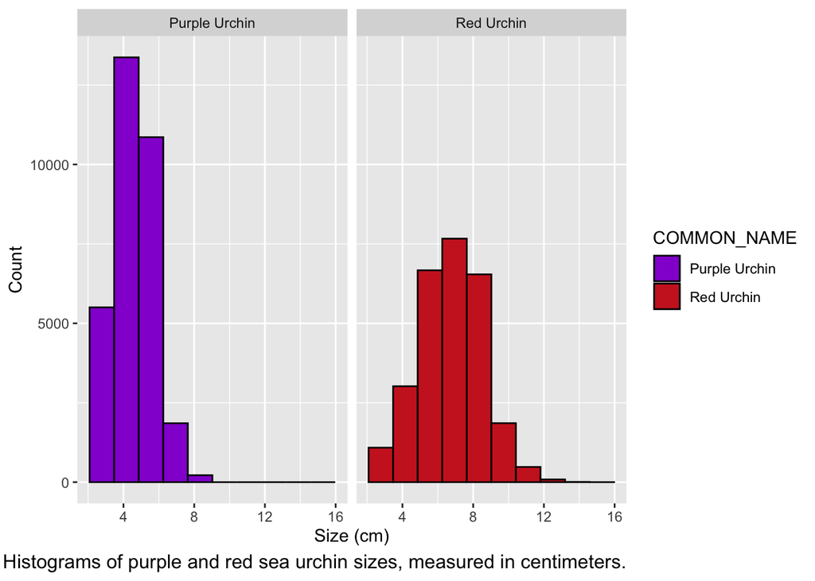

```r
ggplot(data = urchins, aes(x = SIZE)) + #designating the data and x variable
  geom_histogram(bins = 10, color = "gray0", aes(fill = COMMON_NAME)) + #selecting a histogram, designating bin number, color coding by species, and adding outlines
  scale_fill_manual(values = c("darkviolet", "firebrick3")) + #designating color coding
  facet_wrap(~COMMON_NAME) + #splitting the graph by common name
  labs(x = "Size (cm)", #labeling axes
       y = "Count",
       caption = "Histograms of purple and red sea urchin sizes, measured in centimeters.") +
  theme(plot.caption = element_text(size = 12))
```

## 2.2 Data table of urchin statistics

The following data table presents summary statistics for red and purple urchin samples, including mean, median, standard deviation, and sample size.

```r
#getting the summary statistics
urchin_stats <- urchins %>% #start with the urchins data
  group_by(COMMON_NAME) %>% #group our table by urchin species
  summarize(mean = mean(SIZE), #create a column for the mean of urchin sizes
            median = median(SIZE), #create a column for the median of urchin sizes
            sd = sd(SIZE), #create a column for the standard deviation of urchin sizes
            n = n()) #create a column for the sample size of urchin sizes

#creating a visually pleasing table
urchin_stats_table <- urchin_stats %>%
  kable(digits = c(1, 1, 1, 1, 5), #setting the number of digits for each column; similar to `round()`)
        col.names = c("Species", "Mean (cm)", "Median (cm)", "Standard Deviation (cm)", "Sample Size"), #naming columns
        caption = "Summary statistics for the diameter (size) of purple and red sea urchins recorded by Santa Barbara Coastal Long Term Ecological Research program divers at five long-term kelp removal experiment sites.", #giving the table a caption above
        align = "lcccc") %>%  #aligning the values centrally except for the species column (left aligned)
  kable_styling(full_width = FALSE, position = "center") #setting it to not take up the full page width and be center aligned

urchin_stats_table #calling up the table for reference
```

Summary statistics for the diameter (size) of purple and red sea urchins recorded by Santa Barbara Coastal Long Term Ecological Research program divers at five long-term kelp removal experiment sites.

| Species | Mean (cm) | Median (cm) | Standard Deviation (cm) | Sample Size |
| --- | --- | --- | --- | --- |
| Purple Urchin | 4.5 | 4.5 | 1.2 | 31805 |
| Red Urchin | 6.8 | 7.0 | 1.9 | 27408 |

# 3 Exploring purple urchin counts by site and year

## 3.1 Wrangling data for purple urchins

In a new data frame called purple_urchins, data is filtered to only include purple urchin observations, and new columns are added with the full name of sampling sites and the year of sampling.

```r
purple_urchins <- urchins %>%
  filter(COMMON_NAME == "Purple Urchin") %>%
  mutate(DATE = mdy(DATE), #converting DATE column to class "Date"
         YEAR = year(DATE), #creating a new column with just the year
         SITE_FULL = case_when( #add a new column called SITE_FULL with full site names based on abbreviations from the SITE column
           SITE == "NAPL" ~ "Naples Reef",
           SITE == "AQUE" ~ "Arroyo Quemado Reef",
           SITE == "CARP" ~ "Carpinteria Reef",
           SITE == "MOHK" ~ "Mohawk Reef",
           SITE == "IVEE" ~ "Isla Vista Reef"))

head(purple_urchins) #calling up the dataframe for reference
```

```
##         DATE SITE TREATMENT SIZE               SCIENTIFIC_NAME   COMMON_NAME
## 1 2008-10-10 NAPL   CONTROL  2.5 Strongylocentrotus purpuratus Purple Urchin
## 2 2008-10-10 NAPL   CONTROL  2.5 Strongylocentrotus purpuratus Purple Urchin
## 3 2008-10-10 NAPL   CONTROL  2.5 Strongylocentrotus purpuratus Purple Urchin
## 4 2008-10-10 NAPL   CONTROL  2.5 Strongylocentrotus purpuratus Purple Urchin
## 5 2008-10-10 NAPL   CONTROL  2.5 Strongylocentrotus purpuratus Purple Urchin
## 6 2008-10-10 NAPL   CONTROL  2.5 Strongylocentrotus purpuratus Purple Urchin
##   YEAR   SITE_FULL
## 1 2008 Naples Reef
## 2 2008 Naples Reef
## 3 2008 Naples Reef
## 4 2008 Naples Reef
## 5 2008 Naples Reef
## 6 2008 Naples Reef
```

## 3.2 Visualizing purple urchin counts by year and site

This set of histograms will visualize the counts of purple urchins recorded at each sampling site for the years included in the study.

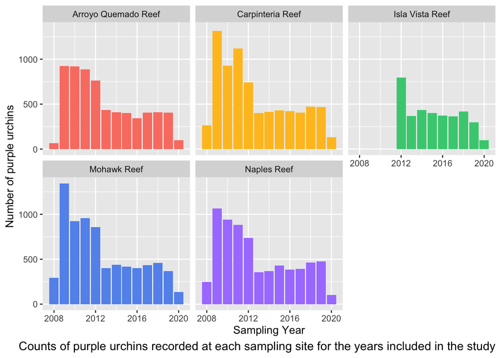

```r
#creating a table with the total number of purple urchins counted at each site per year
purple_urchins_site_year <- purple_urchins %>%
  count(SITE_FULL, YEAR)

#making a finalized graph of counts of purple urchins recorded at each site over time for the years included in the study.

ggplot(data = purple_urchins_site_year, aes(x = YEAR, y = n)) + #designating data set and axes
  geom_col(aes(fill = SITE_FULL), show.legend = FALSE) + #generating a column graph and hiding the legend
   scale_fill_manual(values = c("salmon", "goldenrod1", "seagreen3", "cornflowerblue", "mediumpurple1")) + #designating color coding
  facet_wrap(~SITE_FULL) + #splitting graphs up by year
  labs(x = "Sampling Year",
       y = "Number of purple urchins",
       caption = "Counts of purple urchins recorded at each sampling site for the years included in the study") +
  theme(plot.caption = element_text(size = 12))
```

## 3.3 Takeaway

This graph reflects changes in the sample counts of purple urchins at each site for a given year between 2008 and 2020. However, to determine whether these sample count changes are reflective of changes in the true purple urchin population, we must take into account sampling effort, sampling accuracy, and availability of resources. These counts were taken from random transects within each sampling plot. If fewer transects were taken in a given year than the standard number, or transects happened to be taken in areas that purple urchins were avoiding, then the count would be artificially low. The count could also be artificially high if more transects were taken than the standard, or if transects were taken in areas that were attractive to purple urchins (for example, if food is abundant along a certain transect). Lower availability of resources such as people to take the samples or ability to access the sampling area could lead to reduced sampling efforts as well.